# Data Cleansing

## 2. Handling Missing Values using Scikit-Learn

```python
#from sklearn.preprocessing import Imputer
from sklearn.impute import SimpleImputer
```

### Imputer is a 2-step transformation i.e.,first it fits to the data and then it transforms.

### Imputer works only on the numerical columns

## Imputation is the process of replacing missing data with substituted values

```python
imputer = SimpleImputer(missing_values = np.nan, strategy = "mean")
```

```python
data_impute
```

|  | day | temperature | windspeed | event |
| --- | --- | --- | --- | --- |
| 0 | 2017-01-01 | 32.0 | 6.0 | Rain |
| 1 | 2017-01-02 | NaN | 7.0 | Sunny |
| 2 | 2017-01-03 | 28.0 | NaN | Snow |
| 3 | 2017-01-04 | NaN | 7.0 | NaN |
| 4 | 2017-01-05 | 32.0 | NaN | Rain |
| 5 | 2017-01-06 | 31.0 | 2.0 | Sunny |
| 6 | 2017-01-06 | 34.0 | 5.0 | NaN |

```python
imputer.fit(data_impute.iloc[:,1:3])
```

```
SimpleImputer(add_indicator=False, copy=True, fill_value=None,
              missing_values=nan, strategy='mean', verbose=0)
```

```python
data_impute.iloc[:,1:3] = imputer.transform(data_impute.iloc[:,1:3])
```

```python
data_impute
```

|  | day | temperature | windspeed | event |
| --- | --- | --- | --- | --- |
| 0 | 2017-01-01 | 32.0 | 6.0 | Rain |
| 1 | 2017-01-02 | 31.4 | 7.0 | Sunny |
| 2 | 2017-01-03 | 28.0 | 5.4 | Snow |
| 3 | 2017-01-04 | 31.4 | 7.0 | NaN |
| 4 | 2017-01-05 | 32.0 | 5.4 | Rain |
| 5 | 2017-01-06 | 31.0 | 2.0 | Sunny |
| 6 | 2017-01-06 | 34.0 | 5.0 | NaN |

### As Imputer object works only on the numerical values, for the categorical data we deal with mode

```python
# Problems involved in using Categorical Imputer
# If the categorical imputer is passed a column that contains nothing but empty values it will fail.
# Also, if it is passed a column marked as a categorical, but the columns entries are all unique values, it will fail.
# The most frequent value in this column has a tie and the underlying sklearn-pandas/CategoricalImputer throws the error.

from sklearn_pandas import CategoricalImputer
imputer_cat = CategoricalImputer()
imputer_cat.fit_transform(data_impute.iloc[:,3])
```

[output not shown]

```python
col = ['event']
data_impute[col] = data_impute[col].fillna(data_impute.mode().iloc[0])
```

```python
data_impute
```

|  | day | temperature | windspeed | event |
| --- | --- | --- | --- | --- |
| 0 | 2017-01-01 | 32.0 | 6.0 | Rain |
| 1 | 2017-01-02 | 31.4 | 7.0 | Sunny |
| 2 | 2017-01-03 | 28.0 | 5.4 | Snow |
| 3 | 2017-01-04 | 31.4 | 7.0 | Rain |
| 4 | 2017-01-05 | 32.0 | 5.4 | Rain |
| 5 | 2017-01-06 | 31.0 | 2.0 | Sunny |
| 6 | 2017-01-06 | 34.0 | 5.0 | Rain |

```python
#data['event'] = data['event'].fillna(data.mode().iloc[0])
```

### 3.Mean Imputation

```python
data.fillna(data.mean())
```

|  | day | temperature | windspeed | event |
| --- | --- | --- | --- | --- |
| 0 | 01-01-2017 | 32.0 | 6.0 | Rain |
| 1 | 01-02-2017 | 31.4 | 7.0 | Sunny |
| 2 | 01-03-2017 | 28.0 | 5.4 | Snow |
| 3 | 01-04-2017 | 31.4 | 7.0 | 0 |
| 4 | 01-05-2017 | 32.0 | 5.4 | Rain |
| 5 | 01-06-2017 | 31.0 | 2.0 | Sunny |
| 6 | 01-06-2017 | 34.0 | 5.0 | 0 |

### 3. Median Imputation

```python
data.fillna(data.median())
```

[output not shown]

#### Machine Learning models are based on equations, we need to replace the text by numbers. So that we can include the numbers in the equations.

#### Categorical Variables are of two types: Nominal and Ordinal

##### Nominal: The categories do not have any numeric ordering in between them. They don't have any ordered relationship between each of them.Examples: Male or Female, any colour

##### Ordinal: The categories have a numerical ordering in between them. Example: Graduate is less than Post Graduate, Post Graduate is less than Ph.D, customer satisfaction survey, high low medium

#### Categorical data can be handled by using dummy variables, which are also called as indicator variables.

#### 1. Can be handled using pandas with get_dummies()

```python
price = pd.read_csv(r'C:\Users\Veerabhadra\Documents\DS\Python Scripts\Codebasics  Github\py-master\ML\5_one_hot_encoding\homeprices.csv')
```

```python
price
```

|  | town | area | price |
| --- | --- | --- | --- |
| 0 | monroe township | 2600 | 550000 |
| 1 | monroe township | 3000 | 565000 |
| 2 | monroe township | 3200 | 610000 |
| 3 | monroe township | 3600 | 680000 |
| 4 | monroe township | 4000 | 725000 |
| 5 | west windsor | 2600 | 585000 |
| 6 | west windsor | 2800 | 615000 |
| 7 | west windsor | 3300 | 650000 |
| 8 | west windsor | 3600 | 710000 |
| 9 | robinsville | 2600 | 575000 |
| 10 | robinsville | 2900 | 600000 |
| 11 | robinsville | 3100 | 620000 |
| 12 | robinsville | 3600 | 695000 |

```python
## Convert categorical variable into dummy/indicator variables.

dummy_set = pd.get_dummies(price.town)
dummy_set
```

|  | monroe township | robinsville | west windsor |
| --- | --- | --- | --- |
| 0 | 1 | 0 | 0 |
| 1 | 1 | 0 | 0 |
| 2 | 1 | 0 | 0 |
| 3 | 1 | 0 | 0 |
| 4 | 1 | 0 | 0 |
| 5 | 0 | 0 | 1 |
| 6 | 0 | 0 | 1 |
| 7 | 0 | 0 | 1 |
| 8 | 0 | 0 | 1 |
| 9 | 0 | 1 | 0 |
| 10 | 0 | 1 | 0 |
| 11 | 0 | 1 | 0 |
| 12 | 0 | 1 | 0 |

```python
merged = pd.concat([price, dummy_set], axis = 1)
```

```python
merged
```

|  | town | area | price | monroe township | robinsville | west windsor |
| --- | --- | --- | --- | --- | --- | --- |
| 0 | monroe township | 2600 | 550000 | 1 | 0 | 0 |
| 1 | monroe township | 3000 | 565000 | 1 | 0 | 0 |
| 2 | monroe township | 3200 | 610000 | 1 | 0 | 0 |
| 3 | monroe township | 3600 | 680000 | 1 | 0 | 0 |
| 4 | monroe township | 4000 | 725000 | 1 | 0 | 0 |
| 5 | west windsor | 2600 | 585000 | 0 | 0 | 1 |
| 6 | west windsor | 2800 | 615000 | 0 | 0 | 1 |
| 7 | west windsor | 3300 | 650000 | 0 | 0 | 1 |
| 8 | west windsor | 3600 | 710000 | 0 | 0 | 1 |
| 9 | robinsville | 2600 | 575000 | 0 | 1 | 0 |
| 10 | robinsville | 2900 | 600000 | 0 | 1 | 0 |
| 11 | robinsville | 3100 | 620000 | 0 | 1 | 0 |
| 12 | robinsville | 3600 | 695000 | 0 | 1 | 0 |

```python
#pd.get_dummies(price, columns = ['town'], drop_first = True)
```

#### Dummy Variable Trap:

```
    -The Dummy Variable Trap is a scenario in which the independent variables are multicollinear - a scenario in which
    two or more variables are highly correlated; in simple terms one variable can be predicted from the others.
    - We need to drop the original town column as we have the dummy columns. Also we need to drop one of the dummy
    variables column in order to avoid the multi-collinearity, which creates the problem of dummy variable trap.
    - Hence, one dummy variable is highly correlated with other dummy variables. Using all dummy variables for
    regression models lead to dummy variable trap.And the dummy variable trap mess up the machine learning model
```

```python
final = merged.drop(['town','west windsor'], axis = 1)
```

```python
final
```

|  | area | price | monroe township | robinsville |
| --- | --- | --- | --- | --- |
| 0 | 2600 | 550000 | 1 | 0 |
| 1 | 3000 | 565000 | 1 | 0 |
| 2 | 3200 | 610000 | 1 | 0 |
| 3 | 3600 | 680000 | 1 | 0 |
| 4 | 4000 | 725000 | 1 | 0 |
| 5 | 2600 | 585000 | 0 | 0 |
| 6 | 2800 | 615000 | 0 | 0 |
| 7 | 3300 | 650000 | 0 | 0 |
| 8 | 3600 | 710000 | 0 | 0 |
| 9 | 2600 | 575000 | 0 | 1 |
| 10 | 2900 | 600000 | 0 | 1 |
| 11 | 3100 | 620000 | 0 | 1 |
| 12 | 3600 | 695000 | 0 | 1 |

### Dummy Variables using LabelEncoder

```python
from sklearn.preprocessing import LabelEncoder
le = LabelEncoder()
```

```python
## Using Label Encoder
df_price = price  ##creating
df_price.town = le.fit_transform(price.town)
df_price
```

|  | town | area | price |
| --- | --- | --- | --- |
| 0 | 0 | 2600 | 550000 |
| 1 | 0 | 3000 | 565000 |
| 2 | 0 | 3200 | 610000 |
| 3 | 0 | 3600 | 680000 |
| 4 | 0 | 4000 | 725000 |
| 5 | 2 | 2600 | 585000 |
| 6 | 2 | 2800 | 615000 |
| 7 | 2 | 3300 | 650000 |
| 8 | 2 | 3600 | 710000 |
| 9 | 1 | 2600 | 575000 |
| 10 | 1 | 2900 | 600000 |
| 11 | 1 | 3100 | 620000 |
| 12 | 1 | 3600 | 695000 |

```python
df_price
```

|  | town | area | price |
| --- | --- | --- | --- |
| 0 | 0 | 2600 | 550000 |
| 1 | 0 | 3000 | 565000 |
| 2 | 0 | 3200 | 610000 |
| 3 | 0 | 3600 | 680000 |
| 4 | 0 | 4000 | 725000 |
| 5 | 2 | 2600 | 585000 |
| 6 | 2 | 2800 | 615000 |
| 7 | 2 | 3300 | 650000 |
| 8 | 2 | 3600 | 710000 |
| 9 | 1 | 2600 | 575000 |
| 10 | 1 | 2900 | 600000 |
| 11 | 1 | 3100 | 620000 |
| 12 | 1 | 3600 | 695000 |

### Dummy Variables using OneHotEncoder:

```python
# Using OneHotEncoder
from sklearn.compose import ColumnTransformer
from sklearn.preprocessing import OneHotEncoder
column_transformer = ColumnTransformer(transformers=[('encoder', OneHotEncoder(),[0])], remainder='passthrough')
price = np.array(column_transformer.fit_transform(price))
```

```python
price
```

```
array([[1.00e+00, 0.00e+00, 0.00e+00, 2.60e+03, 5.50e+05],
       [1.00e+00, 0.00e+00, 0.00e+00, 3.00e+03, 5.65e+05],
       [1.00e+00, 0.00e+00, 0.00e+00, 3.20e+03, 6.10e+05],
       [1.00e+00, 0.00e+00, 0.00e+00, 3.60e+03, 6.80e+05],
       [1.00e+00, 0.00e+00, 0.00e+00, 4.00e+03, 7.25e+05],
       [0.00e+00, 0.00e+00, 1.00e+00, 2.60e+03, 5.85e+05],
       [0.00e+00, 0.00e+00, 1.00e+00, 2.80e+03, 6.15e+05],
       [0.00e+00, 0.00e+00, 1.00e+00, 3.30e+03, 6.50e+05],
       [0.00e+00, 0.00e+00, 1.00e+00, 3.60e+03, 7.10e+05],
       [0.00e+00, 1.00e+00, 0.00e+00, 2.60e+03, 5.75e+05],
       [0.00e+00, 1.00e+00, 0.00e+00, 2.90e+03, 6.00e+05],
       [0.00e+00, 1.00e+00, 0.00e+00, 3.10e+03, 6.20e+05],
       [0.00e+00, 1.00e+00, 0.00e+00, 3.60e+03, 6.95e+05]])
```

```python
# converting the array data into dataframe
X = pd.DataFrame(price)
X
```

|  | 0 | 1 | 2 | 3 | 4 |
| --- | --- | --- | --- | --- | --- |
| 0 | 1.0 | 0.0 | 0.0 | 2600.0 | 550000.0 |
| 1 | 1.0 | 0.0 | 0.0 | 3000.0 | 565000.0 |
| 2 | 1.0 | 0.0 | 0.0 | 3200.0 | 610000.0 |
| 3 | 1.0 | 0.0 | 0.0 | 3600.0 | 680000.0 |
| 4 | 1.0 | 0.0 | 0.0 | 4000.0 | 725000.0 |
| 5 | 0.0 | 0.0 | 1.0 | 2600.0 | 585000.0 |
| 6 | 0.0 | 0.0 | 1.0 | 2800.0 | 615000.0 |
| 7 | 0.0 | 0.0 | 1.0 | 3300.0 | 650000.0 |
| 8 | 0.0 | 0.0 | 1.0 | 3600.0 | 710000.0 |
| 9 | 0.0 | 1.0 | 0.0 | 2600.0 | 575000.0 |
| 10 | 0.0 | 1.0 | 0.0 | 2900.0 | 600000.0 |
| 11 | 0.0 | 1.0 | 0.0 | 3100.0 | 620000.0 |
| 12 | 0.0 | 1.0 | 0.0 | 3600.0 | 695000.0 |

```python
#pd.set_option('display.precision',2)
```

##### In Machine Learning in order to access the performance of the classifier.You train the classifier using 'training set' and then test the performance of your classifier on unseen 'test set'. An important point to note is that during training the classifier only uses the training set . The test set must not be used during training the classifier. The test set will only be available during testing the classifier.

1.training set—a subset to train a model.(Model learns patterns between Input and Output)

2.test set—a subset to test the trained model.(To test whether the model has correctly learnt )

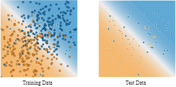

```python
X = price.iloc[:,0:2] # Preparing input variables
X
```

[output not shown]

```python
y = price.price
y
```

```
0     550000
1     565000
2     610000
3     680000
4     725000
5     585000
6     615000
7     650000
8     710000
9     575000
10    600000
11    620000
12    695000
Name: price, dtype: int64
```

```python
from sklearn.model_selection import train_test_split
X_train, X_test, y_train, y_test = train_test_split(X,y, test_size= 0.2, random_state = 0)
```

```python
print(X_train.shape)
print(X_test.shape)
print(y_train.shape)
print(y_test.shape)
```

```
(10, 2)
(3, 2)
(10,)
(3,)
```

#### Feature Scaling means scaling down the values of all the input features with respect to units and magnitude on the same scale.

- All the input variables must be on the same scale.
- Every feature will have units and magnitude(scale)
- Magnitude is the value of the columns and unit is the measurement scale
- Most of the Machine Learning algorithms work the distance based formula; and when there exist a huge difference in magnitude we do not get expected results

```python
sample = pd.DataFrame({"W.E ": [4,2,3,5,6],'Age': [20,25,30,35,40], "Salary": [100000,150000,200000,250000,300000], "Distance":[12,15,4,27,22], "Expected Salary":[200000, 300000, 400000, 450000, 500000]})
sample
```

|  | W.E | Age | Salary | Distance | Expected Salary |
| --- | --- | --- | --- | --- | --- |
| 0 | 4 | 20 | 100000 | 12 | 200000 |
| 1 | 2 | 25 | 150000 | 15 | 300000 |
| 2 | 3 | 30 | 200000 | 4 | 400000 |
| 3 | 5 | 35 | 250000 | 27 | 450000 |
| 4 | 6 | 40 | 300000 | 22 | 500000 |

##### Units is the measurement

- W.E units is in Years
- Age units is in numbers
- Salary units is in Currency(Rupees/Dollars/etc.,)
- Distance units is in Metres
- Expected Salary units is in Currency(Rupees/Dollars/etc.,)

##### Huge difference exists between salary and other columns. Salary is dominating other columns because of scaling issue.

##### As most of the Machine Learning models are based on Euclidean distance, the Euclidean distance gets dominated by the salary. So, we need to put all the variables on the same scale.

```python
from sklearn.preprocessing import scale
scaled_data = scale(sample)
scaled_data
```

```
array([[ 0.        , -1.41421356, -1.41421356, -0.50156986, -1.57841037],
       [-1.41421356, -0.70710678, -0.70710678, -0.12539247, -0.64993368],
       [-0.70710678,  0.        ,  0.        , -1.50470959,  0.27854301],
       [ 0.70710678,  0.70710678,  0.70710678,  1.37931712,  0.74278135],
       [ 1.41421356,  1.41421356,  1.41421356,  0.75235479,  1.2070197 ]])
```

```python
scaled_data= pd.DataFrame(scaled_data)
scaled_data
```

|  | 0 | 1 | 2 | 3 | 4 |
| --- | --- | --- | --- | --- | --- |
| 0 | 0.00 | -1.41 | -1.41 | -0.50 | -1.58 |
| 1 | -1.41 | -0.71 | -0.71 | -0.13 | -0.65 |
| 2 | -0.71 | 0.00 | 0.00 | -1.50 | 0.28 |
| 3 | 0.71 | 0.71 | 0.71 | 1.38 | 0.74 |
| 4 | 1.41 | 1.41 | 1.41 | 0.75 | 1.21 |

```python
# StandardScaler from scikit-learn removes the mean and scales the data to unit standard deviation

from sklearn.preprocessing import StandardScaler
sc = StandardScaler() # create an object
sample = sc.fit_transform(sample) #fit the scaler to the train set, and then transform it
sample
```

```
array([[ 0.        , -1.41421356, -1.41421356, -0.50156986, -1.57841037],
       [-1.41421356, -0.70710678, -0.70710678, -0.12539247, -0.64993368],
       [-0.70710678,  0.        ,  0.        , -1.50470959,  0.27854301],
       [ 0.70710678,  0.70710678,  0.70710678,  1.37931712,  0.74278135],
       [ 1.41421356,  1.41421356,  1.41421356,  0.75235479,  1.2070197 ]])
```

```python
sd = pd.DataFrame(sample)
pd.set_option('display.precision',2)
sd
```

|  | 0 | 1 | 2 | 3 | 4 |
| --- | --- | --- | --- | --- | --- |
| 0 | 0.00 | -1.41 | -1.41 | -0.50 | -1.58 |
| 1 | -1.41 | -0.71 | -0.71 | -0.13 | -0.65 |
| 2 | -0.71 | 0.00 | 0.00 | -1.50 | 0.28 |
| 3 | 0.71 | 0.71 | 0.71 | 1.38 | 0.74 |
| 4 | 1.41 | 1.41 | 1.41 | 0.75 | 1.21 |

```python
from sklearn.preprocessing import StandardScaler
sc = StandardScaler()
sample = sc.fit_transform(sample)
sample
```

```python
# MinMax Scaler will rescale the data set such that all feature values are in the range [0, 1]
from sklearn.preprocessing import MinMaxScaler
sc = MinMaxScaler()
sc.fit(sample)
sample=sc.transform(sample)
```

```python
sample
```

```
array([[0.5       , 0.        , 0.        , 0.34782609, 0.        ],
       [0.        , 0.25      , 0.25      , 0.47826087, 0.33333333],
       [0.25      , 0.5       , 0.5       , 0.        , 0.66666667],
       [0.75      , 0.75      , 0.75      , 1.        , 0.83333333],
       [1.        , 1.        , 1.        , 0.7826087 , 1.        ]])
```

```python
sample=pd.DataFrame(sample)
```

```python
sample.mean()
```

```
0    0.50
1    0.50
2    0.50
3    0.52
4    0.57
dtype: float64
```

```python
sample.std()
```

```
0    0.40
1    0.40
2    0.40
3    0.39
4    0.40
dtype: float64
```